# Lecture 3-2: Functions

# Agenda

# Why Functions?

Data structures tie related values into one object, and functions tie related commands into one object. In both cases: easier to understand, easier to work with, easier to build into larger things.

# What is Function for?

- Things you’re going to re-run, especially if it will be re-run with different data or parameters.
- Chunks of code you keep highlighting and hitting return on.
- Chunks of code which are small parts of bigger analyses.
- Chunks which are very similar to other chunks.

# Example

“Robust” loss function, for outlier-resistant regression Inputs: vector of numbers (x) Outputs: vector with x^2 for small entries, 2|x|-1 for large ones

```r
psi1 <- function(x) {
  psi <-
    ifelse(
      x^2 > 1,
      2 * abs(x) - 1,
      x^2
      )
  return(psi)
}
```

We can use the defined function just like the built-in functions:

```r
z <- c(-0.5,-5,0.9,9)
psi1(z)
```

```
## [1]  0.25  9.00  0.81 17.00
```

**Interfaces**: the **inputs** or **arguments**; the **outputs** or **return value**

Calls other functions `ifelse()`, `abs()`, operators `^` and `>`. `return()` says what the output is.

Comments: one-line description of purpose; listing of arguments; listing of outputs. Not required but very helpful.

# Named and Default Arguments

“Robust” loss function, for outlier-resistant regression Inputs: vector of numbers (x), scale for crossover (c) Outputs: vector with x^2 for small entries, 2*c*|x|-c^2 for large ones

```r
psi2 <- function(x, C = 1) {
  psi <- ifelse(x^2 > C^2, 2 * C * abs(x) - C^2, x^2)
  return(psi)
}

identical(psi1(z), psi2(z, 1))
```

```
## [1] TRUE
```

```r
identical(psi1(z), psi2(z, C = 1))
```

```
## [1] TRUE
```

Default values get used if names are missing:

```r
identical(psi2(z, C = 1), psi2(z))
```

```
## [1] TRUE
```

Named arguments can go in any order when explicitly tagged:

```r
identical(psi2(x = z, C = 2), psi2(C = 2, x = z))
```

```
## [1] TRUE
```

# Checking Arguments

*Problem*: Odd behavior when arguments aren’t as we expect.

```r
psi2(x = z, C = c(1,1,1,10))
```

```
## [1]  0.25  9.00  0.81 81.00
```

```r
psi2(x = z, C = -1)
```

```
## [1]   0.25 -11.00   0.81 -19.00
```

*Solution*: Arguments to `stopifnot()` are a series of expressions which should all be TRUE; execution halts, with error message, at *first* FALSE.

“Robust” loss function, for outlier-resistant regression Inputs: vector of numbers (x), scale for crossover (c) Outputs: vector with x^2 for small entries, 2c|x|-c^2 for large ones

```r
psi3 <- function(x, C = 1) {
  # Scale should be a single positive number
  stopifnot(length(C) == 1, C > 0)
  psi <- ifelse(x^2 > C^2, 2 * C * abs(x) - C^2, x^2)
  return(psi)
}
```

```r
psi3(x = z, C = c(1,1,1,10))
psi3(x = z, C = -1)
```

# Function Environment

- Each function has its own environment.
- Names in the function’s environment override names in the global environment.
- Internal environments start with the named arguments.
- Assignments inside the function only change the internal environment.  
  (There *are* ways around this, but they are difficult and best avoided.)
- Names undefined in the function are looked for in the environment the function gets called from.

# Example 1: Internal Environment

```r
x <- 7
y <- c("A","C","G","T","U")
adder <- function(y) { x <- x + y; return(x) }
adder(1)
```

```
## [1] 8
```

```r
x
```

```
## [1] 7
```

```r
y
```

```
## [1] "A" "C" "G" "T" "U"
```

# Example 2: Internal Environment

```r
circle_area <- function(r) { return(pi * r^2) }
circle_area(c(1, 2, 3))
```

```
## [1]  3.141593 12.566371 28.274334
```

```r
pi <- 3
circle_area(c(1, 2, 3))
```

```
## [1]  3 12 27
```

```r
rm(pi) # Restore sanity
circle_area(c(1, 2, 3))
```

```
## [1]  3.141593 12.566371 28.274334
```

# Ellipsis

The ellipsis argument `...` captures any number of arguments that aren’t otherwise matched. You can use this to provide additional arguments for functions you call from within your function.

Example:

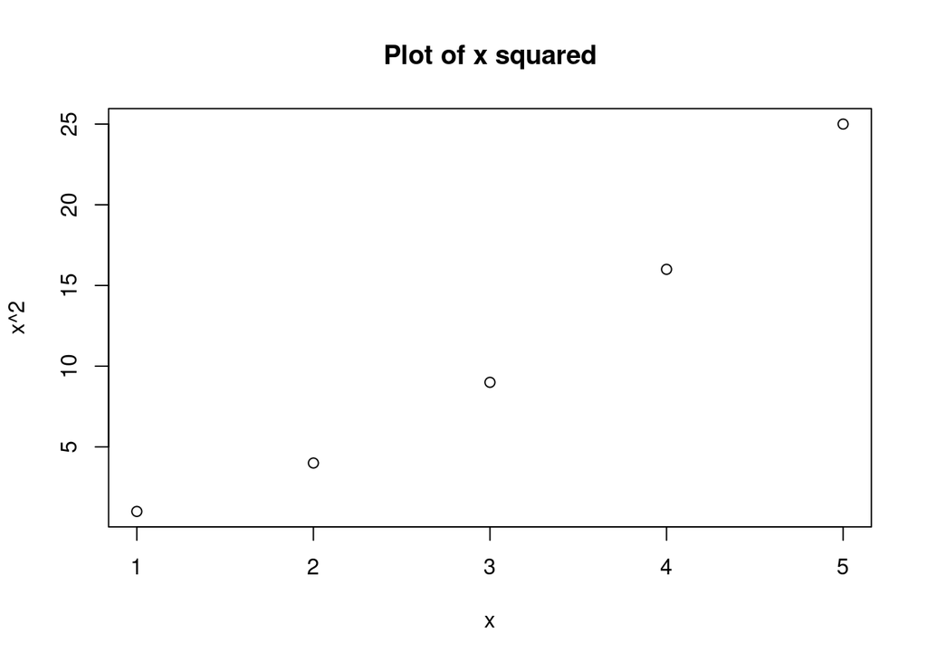

```r
plot_x_squared <- function(x, ...) {
  return(plot(x, x^2, main = "Plot of x squared", ...))
}

plot_x_squared(seq(1:5))
```

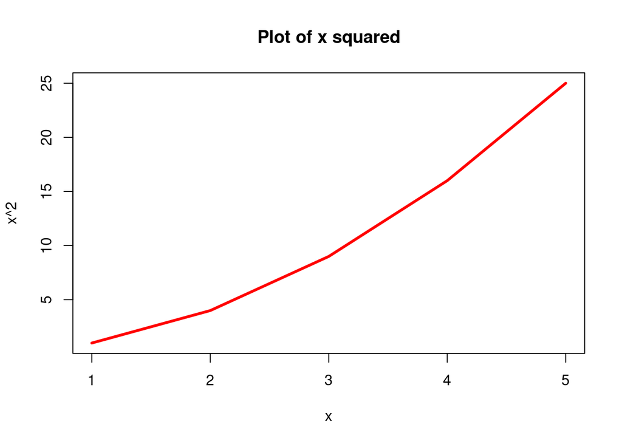

```r
plot_x_squared(seq(1:5), type = "l", col = "red", lwd = 3)
```

But:

```r
plot_x_squared(seq(1:5), type = "l", col = "red", lwd = 3, main = "Haha!")
```

See more at: https://www.r-bloggers.com/r-three-dots-ellipsis/

Exercise: Write a function that samples from the truncated normal distribution and plots a histogram of the sample if the user chooses to do so.

How do we think about this?

1. What is the core task?
2. What are the inputs? (then add defaults, checks)
3. What are the outputs? (the consider adding attributes)

Answer for 1.: sample from the truncated normal distribution. We have seen how to do that:

```r
s <- rnorm(10000)
trunc_s <- s[s > 0.5]
```

But this is partial. This is just the left-truncated normal. We can do this more generally with arbitrary mu, sigma, a and b.

```r
a <- 0.5
b <- Inf
mu <- 0
sigma <- 1
s <- rnorm(10000, mean = mu, sd = sigma)
trunc_s <- s[s > a & s < b]
```

Continuation of the answer for 1.: plot a histogram if wanted.

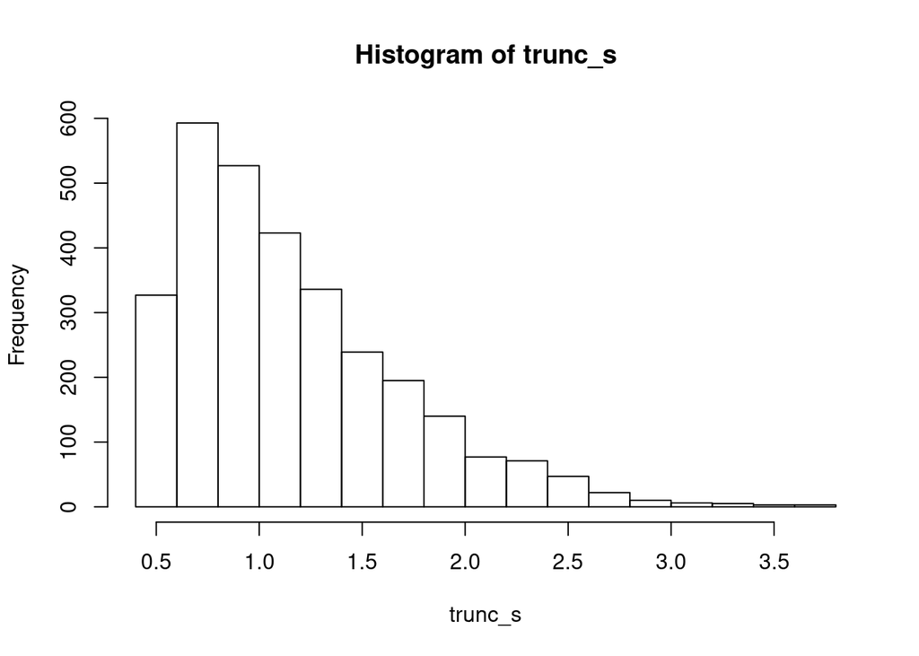

```r
plot_histogram = TRUE
if (plot_histogram) {
  hist(trunc_s)
}
```

Time to make this into a function. 2. What are the inputs? Answer: N (integer), a (double), b (double), mu (double), sigma (double), plot_histogram (logical) 3. what are the outputs? Answer: sample (vector)

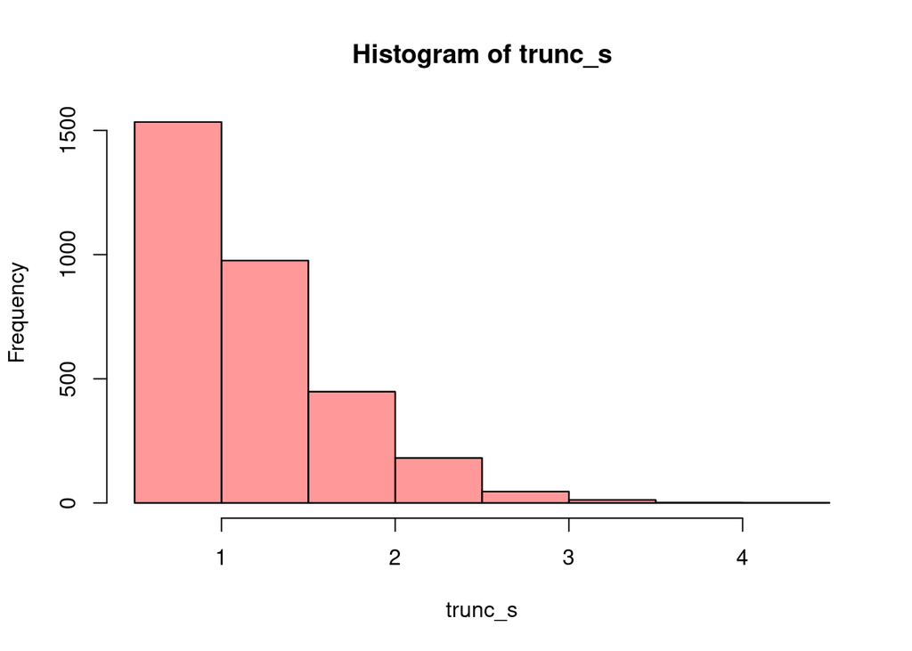

```r
sample_truncated_normal <- function(N, mu, sigma, a, b, plot_histogram) {
  s <- rnorm(N, mean = mu, sd = sigma)
  trunc_s <- s[s > a & s < b]

  if(plot_histogram) {
    hist(trunc_s)
  }

  return(trunc_s)
}

tn_sample <- sample_truncated_normal(10000, 0, 1, 0.5, Inf, TRUE)
hist(tn_sample, add = TRUE, col = rgb(1, 0, 0, 0.4))
```

Think about default values, sanity checks, additional arguments:

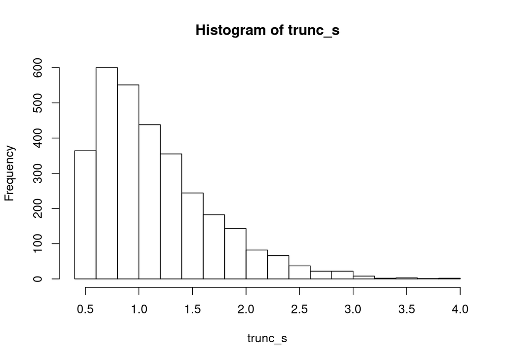

```r
sample_truncated_normal <-
  function(N, mu = 0, sigma = 1, a = -Inf, b = Inf, plot_histogram = FALSE, ...) {
    stopifnot(is.numeric(N), length(N) == 1, !is.na(N))
    stopifnot(is.numeric(mu), length(mu) == 1, !is.na(mu))
    stopifnot(is.numeric(sigma), length(sigma) == 1, !is.na(sigma))
    stopifnot(is.numeric(a), length(a) == 1, !is.na(a))
    stopifnot(is.numeric(b), length(b) == 1, !is.na(b))
    stopifnot(is.logical(plot_histogram))

    s <- rnorm(N, mean = mu, sd = sigma)
    trunc_s <- s[s > a & s < b]

    if(plot_histogram) {
      hist(trunc_s, ...)
    }

    return(trunc_s)
  }

tn_sample <- sample_truncated_normal(10000, a = 0.5, b = Inf)
tn_sample <- sample_truncated_normal(10000, a = 0.5, b = Inf, plot_histogram = TRUE)
```

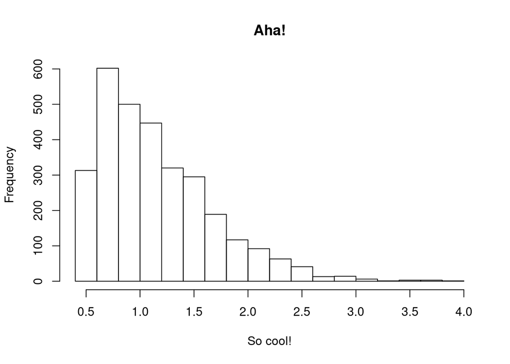

```r
tn_sample <-
  sample_truncated_normal(
    10000,
    a = 0.5,
    b = Inf,
    plot_histogram = TRUE,
    main = "Aha!",
    xlab = "So cool!"
    )
```

But:

```r
tn_sample <- sample_truncated_normal(10000, a = 0.5, b = NA)
tn_sample <- sample_truncated_normal(10000, a = 0.5, b = NaN)
tn_sample <- sample_truncated_normal("10000")
```

Will return an error.

Add some attributes: First, check what are the original attributes of your output, so that you won’t override attributes that were assigned by other functions and that you may want to preserve.

```r
attributes(tn_sample)
```

```r
sample_truncated_normal <-
  function(N, mu = 0, sigma = 1, a = -Inf, b = Inf, plot_histogram = FALSE, ...) {
    s <- rnorm(N, mean = mu, sd = sigma)
    trunc_s <- s[s > a & s < b]

    attributes(trunc_s)$N <- N

    if(plot_histogram) {
      h <- hist(trunc_s, ...)
      attributes(trunc_s)$hist <- h
    }

    return(trunc_s)
  }

tn_sample <- sample_truncated_normal(10000)
str(tn_sample)
```

```
##  num [1:10000] 0.0422 -0.1861 -1.5468 -0.4655 -0.3813 ...
##  - attr(*, "N")= num 10000
```

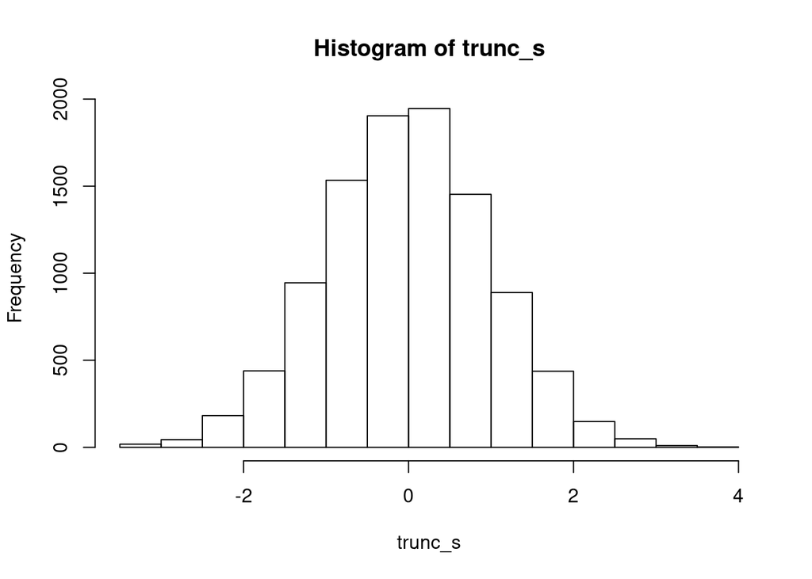

```r
tn_sample <- sample_truncated_normal(10000, plot_histogram = TRUE)
```

```r
str(tn_sample)
```

```
##  num [1:10000] -2.04 0.44 0.159 -0.724 0.131 ...
##  - attr(*, "N")= num 10000
##  - attr(*, "hist")=List of 6
##   ..$ breaks  : num [1:16] -3.5 -3 -2.5 -2 -1.5 -1 -0.5 0 0.5 1 ...
##   ..$ counts  : int [1:15] 18 44 182 439 945 1534 1904 1946 1453 889 ...
##   ..$ density : num [1:15] 0.0036 0.0088 0.0364 0.0878 0.189 ...
##   ..$ mids    : num [1:15] -3.25 -2.75 -2.25 -1.75 -1.25 -0.75 -0.25 0.25 0.75 1.25 ...
##   ..$ xname   : chr "trunc_s"
##   ..$ equidist: logi TRUE
##   ..- attr(*, "class")= chr "histogram"
```

# Using Multiple Functions

- Multiple functions: Doing different things to the same object.
- Sub-functions: Breaking up big jobs into small ones.

*Meta-problems*: When/why you have to write more than one function?

- You’ve got more than one problem.
- Your problem is too hard to solve in one step.
- You keep solving the same problem.

*Meta-solutions*:

- Write multiple functions, which rely on each other.
- Split your problem, and write functions for the pieces.
- Solve the recurring problems once, and re-use the solutions.

We will see an example for this in HW3.

# Summary

- **Functions** bundle related commands together into objects: easier to re-run, easier to re-use, easier to combine, easier to modify, easier to think about, less risk of error.
- **Interfaces** control what the function can see (arguments, environment) and change (its internals, its return value).
- **Calling** functions we define works just like calling built-in functions: named arguments, defaults.
- **Multiple functions** let us do multiple related jobs, either on the same object or on similar ones.
- **Sub-functions** let us break big problems into smaller ones, and re-use the solutions to the smaller ones.